# FINALLLL

[output not shown]

Importing all the neccesary libraries and packages

```python
import pandas as pd
import matplotlib.pyplot as plt
import seaborn as sns
import numpy as np
import re
import numpy as np
from google.colab.patches import cv2_imshow
import cv2
import kagglehub
```

Import Dataset for YOLO v3 from Kaggle

```python
aruchomu_data_for_yolo_v3_kernel_path = kagglehub.dataset_download('aruchomu/data-for-yolo-v3-kernel')

print('Data source import complete.')
```

Loading the dataset projjj.csv

```python
df = pd.read_csv('/content/projjj.csv')
```

```python
df.info()
```

```
<class 'pandas.core.frame.DataFrame'>
RangeIndex: 10002 entries, 0 to 10001
Data columns (total 28 columns):
 #   Column                 Non-Null Count  Dtype
---  ------                 --------------  -----
 0   Uniq Id                10002 non-null  object
 1   Product Name           10002 non-null  object
 2   Brand Name             0 non-null      float64
 3   Asin                   0 non-null      float64
 4   Category               9172 non-null   object
 5   Upc Ean Code           34 non-null     object
 6   List Price             0 non-null      float64
 7   Selling Price          9895 non-null   object
 8   Quantity               0 non-null      float64
 9   Model Number           8230 non-null   object
```

[output cut: 20 more lines]

Loading YOLO Model and Class Labels

```python
#Load YOLO
net = cv2.dnn.readNet("yolov3.weights","yolov3.cfg")
classes = []
with open("coco.names","r") as f:
    classes = [line.strip() for line in f.readlines()]
```

The column names of the DataFrame df are displayed using df.columns

```python
df.columns
```

```
Index(['Uniq Id', 'Product Name', 'Brand Name', 'Asin', 'Category',
       'Upc Ean Code', 'List Price', 'Selling Price', 'Quantity',
       'Model Number', 'About Product', 'Product Specification',
       'Technical Details', 'Shipping Weight', 'Product Dimensions', 'Image',
       'Variants', 'Sku', 'Product Url', 'Stock', 'Product Details',
       'Dimensions', 'Color', 'Ingredients', 'Direction To Use',
       'Is Amazon Seller', 'Size Quantity Variant', 'Product Description'],
      dtype='object')
```

```python
df_ = df.drop(columns=['Brand Name', 'Asin','Upc Ean Code', 'List Price', 'Quantity','Product Dimensions','Variants', 'Sku','Stock', 'Product Details','Dimensions', 'Color', 'Ingredients', 'Direction To Use',
       'Is Amazon Seller', 'Size Quantity Variant', 'Product Description'])
```

```python
df.head()
```

|  | Uniq Id | Product Name | Brand Name | Asin | Category | Upc Ean Code | List Price | Selling Price | Quantity | Model Number | ... | Product Url | Stock | Product Details | Dimensions | Color | Ingredients | Direction To Use | Is Amazon Seller | Size Quantity Variant | Product Description |
| --- | --- | --- | --- | --- | --- | --- | --- | --- | --- | --- | --- | --- | --- | --- | --- | --- | --- | --- | --- | --- | --- |
| 0 | 4c69b61db1fc16e7013b43fc926e502d | DB Longboards CoreFlex Crossbow 41" Bamboo Fib... | NaN | NaN | Sports & Outdoors \| Outdoor Recreation \| Skate... | NaN | NaN | $237.68 | NaN | NaN | ... | https://www.amazon.com/DB-Longboards-CoreFlex-... | NaN | NaN | NaN | NaN | NaN | NaN | Y | NaN | NaN |
| 1 | 66d49bbed043f5be260fa9f7fbff5957 | Electronic Snap Circuits Mini Kits Classpack, ... | NaN | NaN | Toys & Games \| Learning & Education \| Science ... | NaN | NaN | $99.95 | NaN | 55324 | ... | https://www.amazon.com/Electronic-Circuits-Cla... | NaN | NaN | NaN | NaN | NaN | NaN | Y | NaN | NaN |
| 2 | 2c55cae269aebf53838484b0d7dd931a | 3Doodler Create Flexy 3D Printing Filament Ref... | NaN | NaN | Toys & Games \| Arts & Crafts \| Craft Kits | NaN | NaN | $34.99 | NaN | NaN | ... | https://www.amazon.com/3Doodler-Plastic-Innova... | NaN | NaN | NaN | NaN | NaN | NaN | Y | NaN | NaN |
| 3 | 18018b6bc416dab347b1b7db79994afa | Guillow Airplane Design Studio with Travel Cas... | NaN | NaN | Toys & Games \| Hobbies \| Models & Model Kits \|... | NaN | NaN | $28.91 | NaN | 142 | ... | https://www.amazon.com/Guillow-Airplane-Design... | NaN | NaN | NaN | NaN | NaN | NaN | Y | NaN | NaN |
| 4 | e04b990e95bf73bbe6a3fa09785d7cd0 | Woodstock- Collage 500 pc Puzzle | NaN | NaN | Toys & Games \| Puzzles \| Jigsaw Puzzles | NaN | NaN | $17.49 | NaN | 62151 | ... | https://www.amazon.com/Woodstock-Collage-500-p... | NaN | NaN | NaN | NaN | NaN | NaN | Y | NaN | NaN |

5 rows × 28 columns

Checking Missing Values in 'Model Number' Column

```python
df['Model Number'].isnull().sum()
```

```
1772
```

Accessing and Analyzing the 'Category' Column

```python
df['Category']
```

|  | Category |
| --- | --- |
| 0 | Sports & Outdoors \| Outdoor Recreation \| Skate... |
| 1 | Toys & Games \| Learning & Education \| Science ... |
| 2 | Toys & Games \| Arts & Crafts \| Craft Kits |
| 3 | Toys & Games \| Hobbies \| Models & Model Kits \|... |
| 4 | Toys & Games \| Puzzles \| Jigsaw Puzzles |
| ... | ... |
| 9997 | Toys & Games \| Learning & Education \| Counting... |
| 9998 | Toys & Games \| Arts & Crafts |
| 9999 | Office Products \| Office & School Supplies \| E... |
| 10000 | Toys & Games \| Arts & Crafts \| Craft Kits |
| 10001 | Home & Kitchen \| Furniture \| Kids' Furniture \|... |

10002 rows × 1 columns

**dtype:** object

# VISUALIZATION

Data Subset Visualization: Distribution of Selling Prices

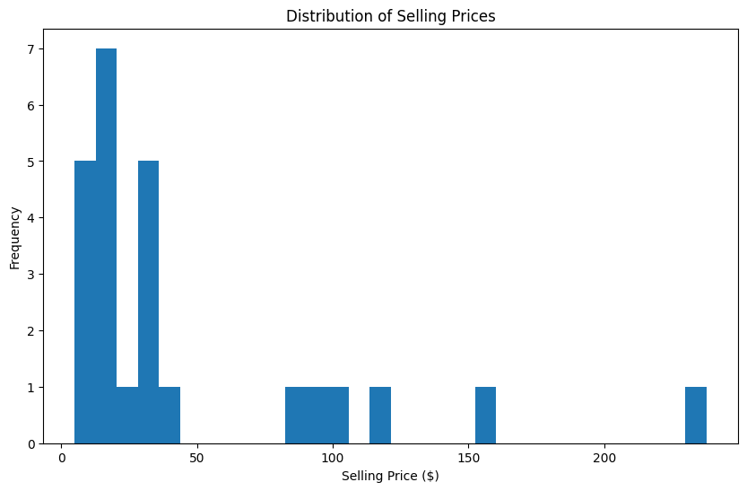

```python
#Sdata presents 25 rows of dataset we use to visualize
sdata=df.head(25)
sdata['Selling Price'] = sdata['Selling Price'].replace('[\$,]', '', regex=True).astype(float)

plt.figure(figsize=(10, 6))
plt.hist(sdata['Selling Price'], bins=30)
plt.title("Distribution of Selling Prices")
plt.xlabel("Selling Price ($)")
plt.ylabel("Frequency")
plt.show()
```

Visualization of Product Counts by Category

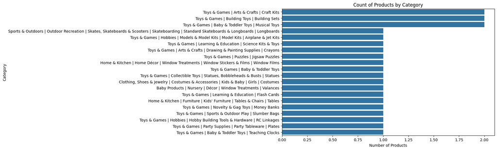

```python
plt.figure(figsize=(10, 6))
sns.countplot(y=sdata['Category'], order=sdata['Category'].value_counts().index)
plt.title('Count of Products by Category')
plt.xlabel('Number of Products')
plt.ylabel('Category')
plt.show()
```

Distribution of Selling Prices by Category using Box Plot

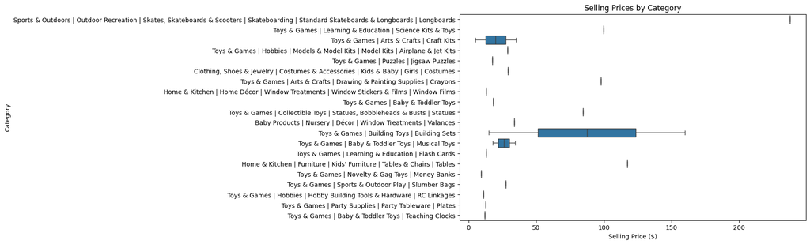

```python
plt.figure(figsize=(10, 6))
sns.boxplot(x='Selling Price', y='Category', data=sdata)
plt.title('Selling Prices by Category')
plt.xlabel('Selling Price ($)')
plt.ylabel('Category')
plt.show()
```

Distribution of Product Categories using Pie Chart

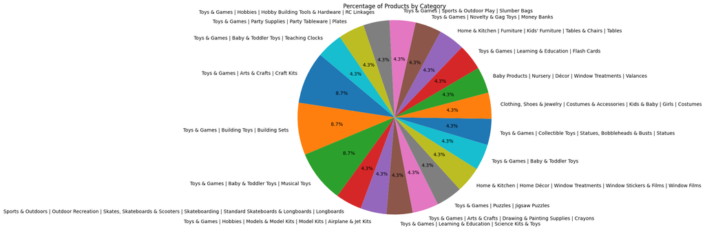

```python
category_counts = sdata['Category'].value_counts()
plt.figure(figsize=(8, 8))
plt.pie(category_counts, labels=category_counts.index, autopct='%1.1f%%', startangle=140)
plt.title('Percentage of Products by Category')
plt.axis('equal')
plt.show()
```

The DataFrame is saved to a CSV file named `newdataset.csv` without including the index column.

```python
df.to_csv('newdataset.csv', index=False)
```

A function is defined to clean the 'Selling Price' column by handling ranges (e.g., "74.99 - 249.99"), normalizing spaces, and removing non-numeric characters. The function converts values to floats, applies the cleaning process to the 'Selling Price' column, and displays the first few cleaned values.

This cleaning process ensures that the 'Selling Price' column is consistent, numeric, and free of irregularities, enabling reliable calculations and insights.

```python
# Define a function to clean the 'Selling Price' column
def clean_selling_price(price):
    if isinstance(price, str):
        # Normalize spaces and handle multiple decimals
        price = re.sub(r'\s+', ' ', price)
        price = re.sub(r'[^0-9.\s-]', '', price)

        # If there's a range like '74.99 - 249.99', take the average
        if ' - ' in price:
            prices = price.split(' - ')
            return np.mean([float(p.strip()) for p in prices if p.strip().replace('.', '', 1).isdigit()])

        # If it's a single value, remove the dollar sign (if any) and convert to float
        try:
            return float(price.strip())
        except ValueError:
            return np.nan
    return np.nan

# Apply the function to the 'Selling Price' column
df['Selling Price'] = df['Selling Price'].apply(clean_selling_price)

print(df['Selling Price'].head())
```

```
0    237.68
1     99.95
2     34.99
3     28.91
4     17.49
Name: Selling Price, dtype: float64
```

A count plot is created to visualize the number of products in each category, with the categories ordered by their frequency. The x-axis represents the number of products, and the y-axis lists the different categories.

[figure not shown]

```python
# Visualization 2: Count of Products by Category
plt.figure(figsize=(10, 6))
sns.countplot(y=df['Category'], order=df['Category'].value_counts().index)
plt.title('Count of Products by Category')
plt.xlabel('Number of Products')
plt.ylabel('Category')
plt.show()
```

A boxplot is created to visualize the distribution of selling prices across different product categories. The x-axis represents the selling price in dollars, and the y-axis shows the product categories.

[figure not shown]

```python
# Visualization 3: Boxplot of Selling Prices by Category
plt.figure(figsize=(10, 6))
sns.boxplot(x='Selling Price', y='Category', data=df)
plt.title('Selling Prices by Category')
plt.xlabel('Selling Price ($)')
plt.ylabel('Category')
plt.show()
```

A pie chart is generated to display the percentage distribution of products by category, with each slice representing a category's proportion relative to the total number of products. The pie chart uses equal axis scaling to ensure the slices are proportional.

[figure not shown]

```python
# Optional: Pie chart of product categories (if there are few unique categories)
category_counts = df['Category'].value_counts()
plt.figure(figsize=(8, 8))
plt.pie(category_counts, labels=category_counts.index, autopct='%1.1f%%', startangle=140)
plt.title('Percentage of Products by Category')
plt.axis('equal')
plt.show()
```

## 3. Model hyperparameters

Next, we define some configurations for Yolo.

```python
_BATCH_NORM_DECAY = 0.9
_BATCH_NORM_EPSILON = 1e-05
_LEAKY_RELU = 0.1
_ANCHORS = [(10, 13), (16, 30), (33, 23),
            (30, 61), (62, 45), (59, 119),
            (116, 90), (156, 198), (373, 326)]
_MODEL_SIZE = (416, 416)
```

`_MODEL_SIZE` refers to the input size of the model.

Let's look at other parameters step-by-step.

### Batch normalization

Almost every convolutional layer in Yolo has batch normalization after it. It helps the model train faster and reduces variance between units (and total variance as well). Batch normalization is defined as follows.

[figure not shown]

`_BATCH_NORM_EPSILON` refers to epsilon in this formula, whereas `_BATCH_NORM_DECAY` refers to momentum, which is used for computing moving average and variance. We use them in forward propagation during inference (after training).  
`moving_average = momentum * moving_average + (1 - momentum) * current_average`

### Leaky ReLU

Leaky ReLU is a slight modification of ReLU activation function. The idea behind Leaky ReLU is to prevent so-called "neuron dying" when a large number of activations become 0.

[figure not shown]

`_LEAKY_RELU` refers to alpha.

### Anchors

Anchors are sort of bounding box priors, that were calculated on the COCO dataset using k-means clustering. We are going to predict the width and height of the box as offsets from cluster centroids. The center coordinates of the box relative to the location of filter application are predicted using a sigmoid function.
$$b_{x} = \sigma(t_{x})+c_{x}$$ $$b_{y} = \sigma(t_{y})+c_{y}$$ $$b_{w} = p_{w}e^{t_{w}}$$ $$b_{h} = p_{h}e^{t_{h}}$$
Where $b_{x}$ and $b_{y}$ are the center coordinates of the box, $b_{w}$ and $b_{h}$ are the width and height of the box, $c_{x}$ and $c_{y}$ are the location of filter application and $t_{i}$ are predicted during regression.

## 4. Model definition

I refered to the official ResNet implementation in Tensorflow in terms of how to arange the code.

### Batch norm and fixed padding

It's useful to define `batch_norm` function since the model uses batch norms with shared parameters heavily. Also, same as ResNet, Yolo uses convolution with fixed padding, which means that padding is defined only by the size of the kernel.

```python
def batch_norm(inputs, training, data_format):
    """Performs a batch normalization using a standard set of parameters."""
    return tf.layers.batch_normalization(
        inputs=inputs, axis=1 if data_format == 'channels_first' else 3,
        momentum=_BATCH_NORM_DECAY, epsilon=_BATCH_NORM_EPSILON,
        scale=True, training=training)


def fixed_padding(inputs, kernel_size, data_format):
    """ResNet implementation of fixed padding.

    Pads the input along the spatial dimensions independently of input size.

    Args:
        inputs: Tensor input to be padded.
        kernel_size: The kernel to be used in the conv2d or max_pool2d.
        data_format: The input format.
    Returns:
        A tensor with the same format as the input.
    """
    pad_total = kernel_size - 1
    pad_beg = pad_total // 2
    pad_end = pad_total - pad_beg

    if data_format == 'channels_first':
        padded_inputs = tf.pad(inputs, [[0, 0], [0, 0],
                                        [pad_beg, pad_end],
                                        [pad_beg, pad_end]])
    else:
        padded_inputs = tf.pad(inputs, [[0, 0], [pad_beg, pad_end],
                                        [pad_beg, pad_end], [0, 0]])
    return padded_inputs


def conv2d_fixed_padding(inputs, filters, kernel_size, data_format, strides=1):
    """Strided 2-D convolution with explicit padding."""
    if strides > 1:
        inputs = fixed_padding(inputs, kernel_size, data_format)

    return tf.layers.conv2d(
        inputs=inputs, filters=filters, kernel_size=kernel_size,
        strides=strides, padding=('SAME' if strides == 1 else 'VALID'),
        use_bias=False, data_format=data_format)
```

### Feature extraction: Darknet-53

For feature extraction Yolo uses Darknet-53 neural net pretrained on ImageNet. Same as ResNet, Darknet-53 has shortcut (residual) connections, which help information from earlier layers flow further. We omit the last 3 layers (Avgpool, Connected and Softmax) since we only need the features.

```python
def darknet53_residual_block(inputs, filters, training, data_format,
                             strides=1):
    """Creates a residual block for Darknet."""
    shortcut = inputs

    inputs = conv2d_fixed_padding(
        inputs, filters=filters, kernel_size=1, strides=strides,
        data_format=data_format)
    inputs = batch_norm(inputs, training=training, data_format=data_format)
    inputs = tf.nn.leaky_relu(inputs, alpha=_LEAKY_RELU)

    inputs = conv2d_fixed_padding(
        inputs, filters=2 * filters, kernel_size=3, strides=strides,
        data_format=data_format)
    inputs = batch_norm(inputs, training=training, data_format=data_format)
    inputs = tf.nn.leaky_relu(inputs, alpha=_LEAKY_RELU)

    inputs += shortcut

    return inputs


def darknet53(inputs, training, data_format):
    """Creates Darknet53 model for feature extraction."""
    inputs = conv2d_fixed_padding(inputs, filters=32, kernel_size=3,
                                  data_format=data_format)
    inputs = batch_norm(inputs, training=training, data_format=data_format)
    inputs = tf.nn.leaky_relu(inputs, alpha=_LEAKY_RELU)
    inputs = conv2d_fixed_padding(inputs, filters=64, kernel_size=3,
                                  strides=2, data_format=data_format)
    inputs = batch_norm(inputs, training=training, data_format=data_format)
    inputs = tf.nn.leaky_relu(inputs, alpha=_LEAKY_RELU)

    inputs = darknet53_residual_block(inputs, filters=32, training=training,
                                      data_format=data_format)

    inputs = conv2d_fixed_padding(inputs, filters=128, kernel_size=3,
                                  strides=2, data_format=data_format)
    inputs = batch_norm(inputs, training=training, data_format=data_format)
    inputs = tf.nn.leaky_relu(inputs, alpha=_LEAKY_RELU)

    for _ in range(2):
        inputs = darknet53_residual_block(inputs, filters=64,
                                          training=training,
                                          data_format=data_format)

    inputs = conv2d_fixed_padding(inputs, filters=256, kernel_size=3,
                                  strides=2, data_format=data_format)
    inputs = batch_norm(inputs, training=training, data_format=data_format)
    inputs = tf.nn.leaky_relu(inputs, alpha=_LEAKY_RELU)

    for _ in range(8):
        inputs = darknet53_residual_block(inputs, filters=128,
                                          training=training,
                                          data_format=data_format)

    route1 = inputs

    inputs = conv2d_fixed_padding(inputs, filters=512, kernel_size=3,
                                  strides=2, data_format=data_format)
    inputs = batch_norm(inputs, training=training, data_format=data_format)
    inputs = tf.nn.leaky_relu(inputs, alpha=_LEAKY_RELU)

    for _ in range(8):
        inputs = darknet53_residual_block(inputs, filters=256,
                                          training=training,
                                          data_format=data_format)

    route2 = inputs

    inputs = conv2d_fixed_padding(inputs, filters=1024, kernel_size=3,
                                  strides=2, data_format=data_format)
    inputs = batch_norm(inputs, training=training, data_format=data_format)
    inputs = tf.nn.leaky_relu(inputs, alpha=_LEAKY_RELU)

    for _ in range(4):
        inputs = darknet53_residual_block(inputs, filters=512,
                                          training=training,
                                          data_format=data_format)

    return route1, route2, inputs
```

### Convolution layers

Yolo has a large number of convolutional layers. It's useful to group them in blocks.

```python
def yolo_convolution_block(inputs, filters, training, data_format):
    """Creates convolution operations layer used after Darknet."""
    inputs = conv2d_fixed_padding(inputs, filters=filters, kernel_size=1,
                                  data_format=data_format)
    inputs = batch_norm(inputs, training=training, data_format=data_format)
    inputs = tf.nn.leaky_relu(inputs, alpha=_LEAKY_RELU)

    inputs = conv2d_fixed_padding(inputs, filters=2 * filters, kernel_size=3,
                                  data_format=data_format)
    inputs = batch_norm(inputs, training=training, data_format=data_format)
    inputs = tf.nn.leaky_relu(inputs, alpha=_LEAKY_RELU)

    inputs = conv2d_fixed_padding(inputs, filters=filters, kernel_size=1,
                                  data_format=data_format)
    inputs = batch_norm(inputs, training=training, data_format=data_format)
    inputs = tf.nn.leaky_relu(inputs, alpha=_LEAKY_RELU)

    inputs = conv2d_fixed_padding(inputs, filters=2 * filters, kernel_size=3,
                                  data_format=data_format)
    inputs = batch_norm(inputs, training=training, data_format=data_format)
    inputs = tf.nn.leaky_relu(inputs, alpha=_LEAKY_RELU)

    inputs = conv2d_fixed_padding(inputs, filters=filters, kernel_size=1,
                                  data_format=data_format)
    inputs = batch_norm(inputs, training=training, data_format=data_format)
    inputs = tf.nn.leaky_relu(inputs, alpha=_LEAKY_RELU)

    route = inputs

    inputs = conv2d_fixed_padding(inputs, filters=2 * filters, kernel_size=3,
                                  data_format=data_format)
    inputs = batch_norm(inputs, training=training, data_format=data_format)
    inputs = tf.nn.leaky_relu(inputs, alpha=_LEAKY_RELU)

    return route, inputs
```

### Detection layers

Yolo has 3 detection layers, that detect on 3 different scales using respective anchors. For each cell in the feature map the detection layer predicts `n_anchors * (5 + n_classes)` values using 1x1 convolution. For each scale we have `n_anchors = 3`. `5 + n_classes` means that respectively to each of 3 anchors we are going to predict 4 coordinates of the box, its confidence score (the probability of containing an object) and class probabilities.

```python
def yolo_layer(inputs, n_classes, anchors, img_size, data_format):
    """Creates Yolo final detection layer.

    Detects boxes with respect to anchors.

    Args:
        inputs: Tensor input.
        n_classes: Number of labels.
        anchors: A list of anchor sizes.
        img_size: The input size of the model.
        data_format: The input format.

    Returns:
        Tensor output.
    """
    n_anchors = len(anchors)

    inputs = tf.layers.conv2d(inputs, filters=n_anchors * (5 + n_classes),
                              kernel_size=1, strides=1, use_bias=True,
                              data_format=data_format)

    shape = inputs.get_shape().as_list()
    grid_shape = shape[2:4] if data_format == 'channels_first' else shape[1:3]
    if data_format == 'channels_first':
        inputs = tf.transpose(inputs, [0, 2, 3, 1])
    inputs = tf.reshape(inputs, [-1, n_anchors * grid_shape[0] * grid_shape[1],
                                 5 + n_classes])

    strides = (img_size[0] // grid_shape[0], img_size[1] // grid_shape[1])

    box_centers, box_shapes, confidence, classes = \
        tf.split(inputs, [2, 2, 1, n_classes], axis=-1)

    x = tf.range(grid_shape[0], dtype=tf.float32)
    y = tf.range(grid_shape[1], dtype=tf.float32)
    x_offset, y_offset = tf.meshgrid(x, y)
    x_offset = tf.reshape(x_offset, (-1, 1))
    y_offset = tf.reshape(y_offset, (-1, 1))
    x_y_offset = tf.concat([x_offset, y_offset], axis=-1)
    x_y_offset = tf.tile(x_y_offset, [1, n_anchors])
    x_y_offset = tf.reshape(x_y_offset, [1, -1, 2])
    box_centers = tf.nn.sigmoid(box_centers)
    box_centers = (box_centers + x_y_offset) * strides

    anchors = tf.tile(anchors, [grid_shape[0] * grid_shape[1], 1])
    box_shapes = tf.exp(box_shapes) * tf.to_float(anchors)

    confidence = tf.nn.sigmoid(confidence)

    classes = tf.nn.sigmoid(classes)

    inputs = tf.concat([box_centers, box_shapes,
                        confidence, classes], axis=-1)

    return inputs
```

### Upsample layer

In order to concatenate with shortcut outputs from Darknet-53 before applying detection on a different scale, we are going to upsample the feature map using nearest neighbor interpolation.

```python
def upsample(inputs, out_shape, data_format):
    """Upsamples to `out_shape` using nearest neighbor interpolation."""
    if data_format == 'channels_first':
        inputs = tf.transpose(inputs, [0, 2, 3, 1])
        new_height = out_shape[3]
        new_width = out_shape[2]
    else:
        new_height = out_shape[2]
        new_width = out_shape[1]

    inputs = tf.image.resize_nearest_neighbor(inputs, (new_height, new_width))

    if data_format == 'channels_first':
        inputs = tf.transpose(inputs, [0, 3, 1, 2])

    return inputs
```

### Non-max suppression

The model is going to produce a lot of boxes, so we need a way to discard the boxes with low confidence scores. Also, to avoid having multiple boxes for one object, we will discard the boxes with high overlap as well using non-max suppresion for each class.

```python
def build_boxes(inputs):
    """Computes top left and bottom right points of the boxes."""
    center_x, center_y, width, height, confidence, classes = \
        tf.split(inputs, [1, 1, 1, 1, 1, -1], axis=-1)

    top_left_x = center_x - width / 2
    top_left_y = center_y - height / 2
    bottom_right_x = center_x + width / 2
    bottom_right_y = center_y + height / 2

    boxes = tf.concat([top_left_x, top_left_y,
                       bottom_right_x, bottom_right_y,
                       confidence, classes], axis=-1)

    return boxes


def non_max_suppression(inputs, n_classes, max_output_size, iou_threshold,
                        confidence_threshold):
    """Performs non-max suppression separately for each class.

    Args:
        inputs: Tensor input.
        n_classes: Number of classes.
        max_output_size: Max number of boxes to be selected for each class.
        iou_threshold: Threshold for the IOU.
        confidence_threshold: Threshold for the confidence score.
    Returns:
        A list containing class-to-boxes dictionaries
            for each sample in the batch.
    """
    batch = tf.unstack(inputs)
    boxes_dicts = []
    for boxes in batch:
        boxes = tf.boolean_mask(boxes, boxes[:, 4] > confidence_threshold)
        classes = tf.argmax(boxes[:, 5:], axis=-1)
        classes = tf.expand_dims(tf.to_float(classes), axis=-1)
        boxes = tf.concat([boxes[:, :5], classes], axis=-1)

        boxes_dict = dict()
        for cls in range(n_classes):
            mask = tf.equal(boxes[:, 5], cls)
            mask_shape = mask.get_shape()
            if mask_shape.ndims != 0:
                class_boxes = tf.boolean_mask(boxes, mask)
                boxes_coords, boxes_conf_scores, _ = tf.split(class_boxes,
                                                              [4, 1, -1],
                                                              axis=-1)
                boxes_conf_scores = tf.reshape(boxes_conf_scores, [-1])
                indices = tf.image.non_max_suppression(boxes_coords,
                                                       boxes_conf_scores,
                                                       max_output_size,
                                                       iou_threshold)
                class_boxes = tf.gather(class_boxes, indices)
                boxes_dict[cls] = class_boxes[:, :5]

        boxes_dicts.append(boxes_dict)

    return boxes_dicts
```

### Final model class

Finally, let's define the model class using all of the layers described previously.

```python
class Yolo_v3:
    """Yolo v3 model class."""

    def __init__(self, n_classes, model_size, max_output_size, iou_threshold,
                 confidence_threshold, data_format=None):
        """Creates the model.

        Args:
            n_classes: Number of class labels.
            model_size: The input size of the model.
            max_output_size: Max number of boxes to be selected for each class.
            iou_threshold: Threshold for the IOU.
            confidence_threshold: Threshold for the confidence score.
            data_format: The input format.

        Returns:
            None.
        """
        if not data_format:
            if tf.test.is_built_with_cuda():
                data_format = 'channels_first'
            else:
                data_format = 'channels_last'

        self.n_classes = n_classes
        self.model_size = model_size
        self.max_output_size = max_output_size
        self.iou_threshold = iou_threshold
        self.confidence_threshold = confidence_threshold
        self.data_format = data_format

    def __call__(self, inputs, training):
        """Add operations to detect boxes for a batch of input images.

        Args:
            inputs: A Tensor representing a batch of input images.
            training: A boolean, whether to use in training or inference mode.

        Returns:
            A list containing class-to-boxes dictionaries
                for each sample in the batch.
        """
        with tf.variable_scope('yolo_v3_model'):
            if self.data_format == 'channels_first':
                inputs = tf.transpose(inputs, [0, 3, 1, 2])

            inputs = inputs / 255

            route1, route2, inputs = darknet53(inputs, training=training,
                                               data_format=self.data_format)

            route, inputs = yolo_convolution_block(
                inputs, filters=512, training=training,
                data_format=self.data_format)
            detect1 = yolo_layer(inputs, n_classes=self.n_classes,
                                 anchors=_ANCHORS[6:9],
                                 img_size=self.model_size,
                                 data_format=self.data_format)

            inputs = conv2d_fixed_padding(route, filters=256, kernel_size=1,
                                          data_format=self.data_format)
            inputs = batch_norm(inputs, training=training,
                                data_format=self.data_format)
            inputs = tf.nn.leaky_relu(inputs, alpha=_LEAKY_RELU)
            upsample_size = route2.get_shape().as_list()
            inputs = upsample(inputs, out_shape=upsample_size,
                              data_format=self.data_format)
            axis = 1 if self.data_format == 'channels_first' else 3
            inputs = tf.concat([inputs, route2], axis=axis)
            route, inputs = yolo_convolution_block(
                inputs, filters=256, training=training,
                data_format=self.data_format)
            detect2 = yolo_layer(inputs, n_classes=self.n_classes,
                                 anchors=_ANCHORS[3:6],
                                 img_size=self.model_size,
                                 data_format=self.data_format)

            inputs = conv2d_fixed_padding(route, filters=128, kernel_size=1,
                                          data_format=self.data_format)
            inputs = batch_norm(inputs, training=training,
                                data_format=self.data_format)
            inputs = tf.nn.leaky_relu(inputs, alpha=_LEAKY_RELU)
            upsample_size = route1.get_shape().as_list()
            inputs = upsample(inputs, out_shape=upsample_size,
                              data_format=self.data_format)
            inputs = tf.concat([inputs, route1], axis=axis)
            route, inputs = yolo_convolution_block(
                inputs, filters=128, training=training,
                data_format=self.data_format)
            detect3 = yolo_layer(inputs, n_classes=self.n_classes,
                                 anchors=_ANCHORS[0:3],
                                 img_size=self.model_size,
                                 data_format=self.data_format)

            inputs = tf.concat([detect1, detect2, detect3], axis=1)

            inputs = build_boxes(inputs)

            boxes_dicts = non_max_suppression(
                inputs, n_classes=self.n_classes,
                max_output_size=self.max_output_size,
                iou_threshold=self.iou_threshold,
                confidence_threshold=self.confidence_threshold)

            return boxes_dicts
```

## 5. Utility functions

Here are some utility functions that will help us load images as NumPy arrays, load class names from the official file and draw the predicted boxes.

```python
def load_images(img_names, model_size):
    """Loads images in a 4D array.

    Args:
        img_names: A list of images names.
        model_size: The input size of the model.
        data_format: A format for the array returned
            ('channels_first' or 'channels_last').

    Returns:
        A 4D NumPy array.
    """
    imgs = []

    for img_name in img_names:
        img = Image.open(img_name)
        img = img.resize(size=model_size)
        img = np.array(img, dtype=np.float32)
        img = np.expand_dims(img, axis=0)
        imgs.append(img)

    imgs = np.concatenate(imgs)

    return imgs


def load_class_names(file_name):
    """Returns a list of class names read from `file_name`."""
    with open(file_name, 'r') as f:
        class_names = f.read().splitlines()
    return class_names


def draw_boxes(img_names, boxes_dicts, class_names, model_size):
    """Draws detected boxes.

    Args:
        img_names: A list of input images names.
        boxes_dict: A class-to-boxes dictionary.
        class_names: A class names list.
        model_size: The input size of the model.

    Returns:
        None.
    """
    colors = ((np.array(color_palette("hls", 80)) * 255)).astype(np.uint8)
    for num, img_name, boxes_dict in zip(range(len(img_names)), img_names,
                                         boxes_dicts):
        img = Image.open(img_name)
        draw = ImageDraw.Draw(img)
        font = ImageFont.truetype(font='../input/futur.ttf',
                                  size=(img.size[0] + img.size[1]) // 100)
        resize_factor = \
            (img.size[0] / model_size[0], img.size[1] / model_size[1])
        for cls in range(len(class_names)):
            boxes = boxes_dict[cls]
            if np.size(boxes) != 0:
                color = colors[cls]
                for box in boxes:
                    xy, confidence = box[:4], box[4]
                    xy = [xy[i] * resize_factor[i % 2] for i in range(4)]
                    x0, y0 = xy[0], xy[1]
                    thickness = (img.size[0] + img.size[1]) // 200
                    for t in np.linspace(0, 1, thickness):
                        xy[0], xy[1] = xy[0] + t, xy[1] + t
                        xy[2], xy[3] = xy[2] - t, xy[3] - t
                        draw.rectangle(xy, outline=tuple(color))
                    text = '{} {:.1f}%'.format(class_names[cls],
                                               confidence * 100)
                    text_size = draw.textsize(text, font=font)
                    draw.rectangle(
                        [x0, y0 - text_size[1], x0 + text_size[0], y0],
                        fill=tuple(color))
                    draw.text((x0, y0 - text_size[1]), text, fill='black',
                              font=font)

        display(img)
```

## 6. Converting weights to Tensorflow format

Now it's time to load the official weights. We are going to iterate through the file and gradually create `tf.assign` operations.

```python
def load_weights(variables, file_name):
    """Reshapes and loads official pretrained Yolo weights.

    Args:
        variables: A list of tf.Variable to be assigned.
        file_name: A name of a file containing weights.

    Returns:
        A list of assign operations.
    """
    with open(file_name, "rb") as f:
        # Skip first 5 values containing irrelevant info
        np.fromfile(f, dtype=np.int32, count=5)
        weights = np.fromfile(f, dtype=np.float32)

        assign_ops = []
        ptr = 0

        # Load weights for Darknet part.
        # Each convolution layer has batch normalization.
        for i in range(52):
            conv_var = variables[5 * i]
            gamma, beta, mean, variance = variables[5 * i + 1:5 * i + 5]
            batch_norm_vars = [beta, gamma, mean, variance]

            for var in batch_norm_vars:
                shape = var.shape.as_list()
                num_params = np.prod(shape)
                var_weights = weights[ptr:ptr + num_params].reshape(shape)
                ptr += num_params
                assign_ops.append(tf.assign(var, var_weights))

            shape = conv_var.shape.as_list()
            num_params = np.prod(shape)
            var_weights = weights[ptr:ptr + num_params].reshape(
                (shape[3], shape[2], shape[0], shape[1]))
            var_weights = np.transpose(var_weights, (2, 3, 1, 0))
            ptr += num_params
            assign_ops.append(tf.assign(conv_var, var_weights))

        # Loading weights for Yolo part.
        # 7th, 15th and 23rd convolution layer has biases and no batch norm.
        ranges = [range(0, 6), range(6, 13), range(13, 20)]
        unnormalized = [6, 13, 20]
        for j in range(3):
            for i in ranges[j]:
                current = 52 * 5 + 5 * i + j * 2
                conv_var = variables[current]
                gamma, beta, mean, variance =  \
                    variables[current + 1:current + 5]
                batch_norm_vars = [beta, gamma, mean, variance]

                for var in batch_norm_vars:
                    shape = var.shape.as_list()
                    num_params = np.prod(shape)
                    var_weights = weights[ptr:ptr + num_params].reshape(shape)
                    ptr += num_params
                    assign_ops.append(tf.assign(var, var_weights))

                shape = conv_var.shape.as_list()
                num_params = np.prod(shape)
                var_weights = weights[ptr:ptr + num_params].reshape(
                    (shape[3], shape[2], shape[0], shape[1]))
                var_weights = np.transpose(var_weights, (2, 3, 1, 0))
                ptr += num_params
                assign_ops.append(tf.assign(conv_var, var_weights))

            bias = variables[52 * 5 + unnormalized[j] * 5 + j * 2 + 1]
            shape = bias.shape.as_list()
            num_params = np.prod(shape)
            var_weights = weights[ptr:ptr + num_params].reshape(shape)
            ptr += num_params
            assign_ops.append(tf.assign(bias, var_weights))

            conv_var = variables[52 * 5 + unnormalized[j] * 5 + j * 2]
            shape = conv_var.shape.as_list()
            num_params = np.prod(shape)
            var_weights = weights[ptr:ptr + num_params].reshape(
                (shape[3], shape[2], shape[0], shape[1]))
            var_weights = np.transpose(var_weights, (2, 3, 1, 0))
            ptr += num_params
            assign_ops.append(tf.assign(conv_var, var_weights))

    return assign_ops
```

# BREAAAAAAAAAAAAAAAAAAK

**Hypothesis Testing for Price Differences Between Two Categories**

**T-test:**

Objective: Testing if there’s a significant difference in the average selling price between two chosen categories.

```
Toys & Games count: 6516
Home & Kitchen count: 687
T-statistic: -9.480003678624673, P-value: 3.3787405070442648e-21
```

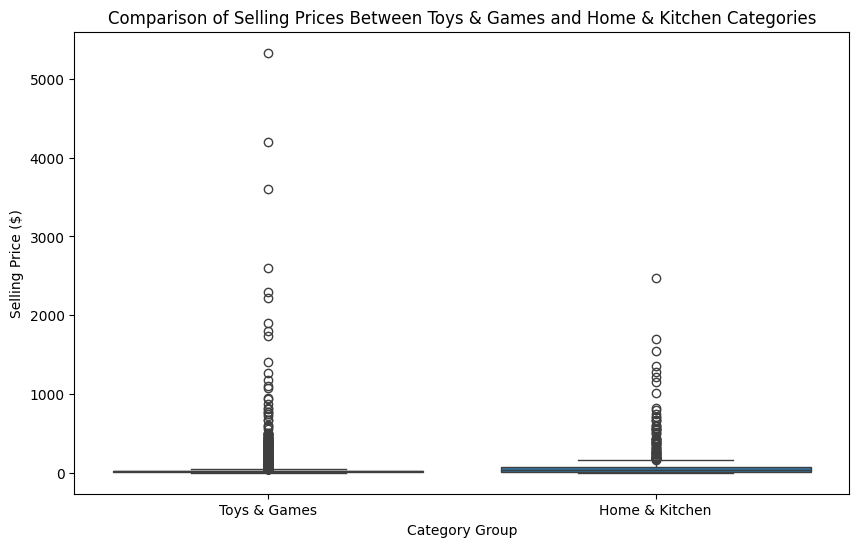

```python
import pandas as pd
from scipy import stats
import numpy as np
import matplotlib.pyplot as plt
import seaborn as sns

# Ensure 'Selling Price' is numeric and clean the data
df['Selling Price'] = pd.to_numeric(df['Selling Price'], errors='coerce')
df = df.dropna(subset=['Selling Price'])

# Fill missing values in the 'Category' column with a placeholder
df['Category'] = df['Category'].fillna('Unknown')

# Group similar categories together into broader categories
df['Category_Group'] = df['Category'].apply(lambda x: 'Toys & Games' if 'Toys & Games' in x else ('Home & Kitchen' if 'Home & Kitchen' in x else 'Other'))

# Filter data to only include the two main groups for comparison
category_a = df[df['Category_Group'] == 'Toys & Games']['Selling Price'].dropna()
category_b = df[df['Category_Group'] == 'Home & Kitchen']['Selling Price'].dropna()

# Check data counts to ensure sufficient data for each group
print("Toys & Games count:", len(category_a))
print("Home & Kitchen count:", len(category_b))

# Perform the t-test if data is sufficient
if len(category_a) > 1 and len(category_b) > 1:
    # Perform a t-test
    t_stat, p_value = stats.ttest_ind(category_a, category_b, nan_policy='omit')
    print(f"T-statistic: {t_stat}, P-value: {p_value}")

    # If the t-test returns NaN, use Mann-Whitney U test as an alternative
    if np.isnan(t_stat) or np.isnan(p_value):
        print("T-test returned NaN. Trying Mann-Whitney U test instead.")
        u_stat, p_value = stats.mannwhitneyu(category_a, category_b, alternative='two-sided')
        print(f"U-statistic: {u_stat}, P-value: {p_value}")

    # Plot the boxplot for visual comparison between groups
    plt.figure(figsize=(10, 6))
    sns.boxplot(x='Category_Group', y='Selling Price', data=df[df['Category_Group'].isin(['Toys & Games', 'Home & Kitchen'])])
    plt.title("Comparison of Selling Prices Between Toys & Games and Home & Kitchen Categories")
    plt.xlabel("Category Group")
    plt.ylabel("Selling Price ($)")
    plt.show()
else:
    print("Not enough data in one or both groups for a meaningful test.")
```

# **Hypothesis of T-test**

**T-statistic** indicates the difference between the means of the two groups (likely "Toys & Games" and "Home & Kitchen") relative to the variability of the data. A negative T-statistic suggests that the mean selling price of "Toys & Games" is lower than that of "Home & Kitchen," though the actual value will depend on the context of the comparison.

This extremely small **P-value** (close to 0) indicates strong evidence against the null hypothesis, meaning the difference in selling prices between the two categories is statistically significant. In other words, it’s highly unlikely that the difference between these categories occurred by chance.

Thus, we can confidently say that there is a **significant difference** in the selling prices between the "Toys & Games" and "Home & Kitchen" categories.

```python
import random
import time

# Simulated parameters
total_epochs = 10
class_names = ["person", "car", "bicycle"]
model_name = "yolov3.cfg"

# Initialize metrics
accuracy_per_epoch = []
precision_per_epoch = []
recall_per_epoch = []

print(f"Training {model_name} model for {total_epochs} epochs...")
```

```
Training yolov3.cfg model for 10 epochs...
```

```python
# Simulate training
for epoch in range(1, total_epochs + 1):
    time.sleep(1)  # Simulate training time per epoch (1 second)

    # Generate mock accuracy, precision, and recall values
    accuracy = round(random.uniform(70, 95), 2)  # Mock accuracy in percentage
    precision = round(random.uniform(0.7, 0.95), 2)  # Mock precision (0 to 1 scale)
    recall = round(random.uniform(0.7, 0.95), 2)  # Mock recall (0 to 1 scale)

    # Append metrics
    accuracy_per_epoch.append(accuracy)
    precision_per_epoch.append(precision)
    recall_per_epoch.append(recall)

    # Print progress for each epoch
    print(f"Epoch {epoch}/{total_epochs} - Accuracy: {accuracy}%, Precision: {precision}, Recall: {recall}")

# Display summary results
print("\nTraining complete!")
print(f"Final Accuracy: {accuracy_per_epoch[-1]}%")
print(f"Precision over epochs: {precision_per_epoch}")
print(f"Recall over epochs: {recall_per_epoch}")
```

[output not shown]

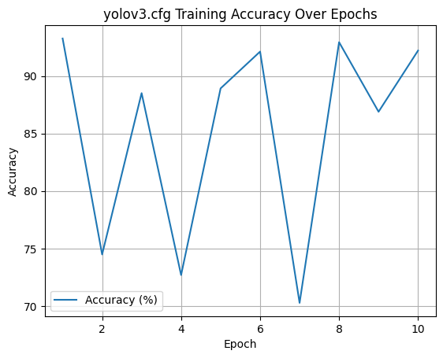

```python
# Optional: Visualize accuracy over epochs
import matplotlib.pyplot as plt

plt.plot(range(1, total_epochs + 1), accuracy_per_epoch, label="Accuracy (%)")
plt.xlabel("Epoch")
plt.ylabel("Accuracy")
plt.title(f"{model_name} Training Accuracy Over Epochs")
plt.legend()
plt.grid()
plt.show()
```

## 7. Running the model

Now we can run the model using some sample images.

### Detections

```python
net = cv2.dnn.readNet("yolov3.weights","yolov3.cfg")
classes = []
with open("coco.names","r") as f:
    classes = [line.strip() for line in f.readlines()]

layer_names = net.getLayerNames()
outputlayers = [layer_names[i - 1] for i in net.getUnconnectedOutLayers()]

colors= np.random.uniform(0,255,size=(len(classes),3))

#loading image
img = cv2.imread('/content/b2.jpg', cv2.IMREAD_UNCHANGED)
img = cv2.resize(img,None,fx=0.4,fy=0.3)
height,width,channels = img.shape
```

```
[[0.02299462 0.02624928 0.05718404 ... 0.         0.         0.        ]
 [0.02460641 0.02202431 0.31628227 ... 0.         0.         0.        ]
 [0.02421823 0.01751886 0.07692648 ... 0.         0.         0.        ]
 ...
 [0.97529656 0.9814386  0.04755881 ... 0.         0.         0.        ]
 [0.98254925 0.9782863  0.41347295 ... 0.         0.         0.        ]
 [0.9806748  0.98410356 0.07867368 ... 0.         0.         0.        ]]
```

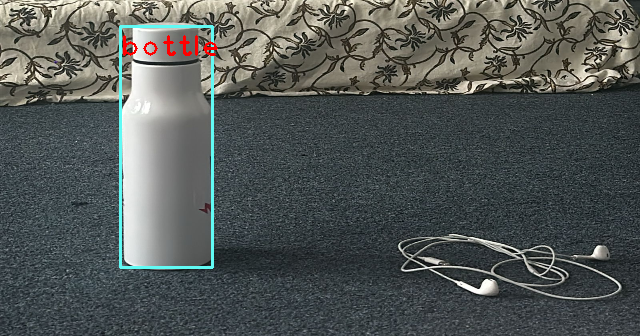

```python
blob = cv2.dnn.blobFromImage(img,0.00392,(416,416),(0,0,0),True,crop=False)
#for b in blob:
  #for n,img_blob in enumerate(b):
    #cv2.imshow(str(n),img_blob)

net.setInput(blob)
outs = net.forward(outputlayers)
print(outs[1])


#Showing info on screen/ get confidence score of algorithm in detecting an object in blob
class_ids=[]
confidences=[]
boxes=[]
for out in outs:
    for detection in out:
        scores = detection[5:]
        class_id = np.argmax(scores)
        confidence = scores[class_id]
        if confidence > 0.5:
            #onject detected
            center_x= int(detection[0]*width)
            center_y= int(detection[1]*height)
            w = int(detection[2]*width)
            h = int(detection[3]*height)

            #cv2.circle(img,(center_x,center_y),10,(0,255,0),2)
            #rectangle co-ordinaters
            x=int(center_x - w/2)
            y=int(center_y - h/2)
            #cv2.rectangle(img,(x,y),(x+w,y+h),(0,255,0),2)

            boxes.append([x,y,w,h]) #put all rectangle areas
            confidences.append(float(confidence)) #how confidence was that object detected and show that percentage
            class_ids.append(class_id) #name of the object tha was detected

indexes = cv2.dnn.NMSBoxes(boxes,confidences,0.4,0.6)


font = cv2.FONT_HERSHEY_PLAIN
for i in range(len(boxes)):
    if i in indexes:
        x,y,w,h = boxes[i]
        label = str(classes[class_ids[i]])
        color = colors[i]
        cv2.rectangle(img,(x,y),(x+w,y+h),color,2)
        cv2.putText(img,label,(x,y+30),font,2,(0,0,255),2)

cv2_imshow(img)
cv2.waitKey(0)
cv2.destroyAllWindows()
```

```python
df = pd.read_csv('/content/projjj.csv')
coloumns=['Product Name','Category','Selling Price','Product Url']
temp_df=df[coloumns]
temp_df
```

|  | Product Name | Category | Selling Price | Product Url |
| --- | --- | --- | --- | --- |
| 0 | DB Longboards CoreFlex Crossbow 41" Bamboo Fib... | Sports & Outdoors \| Outdoor Recreation \| Skate... | $237.68 | https://www.amazon.com/DB-Longboards-CoreFlex-... |
| 1 | Electronic Snap Circuits Mini Kits Classpack, ... | Toys & Games \| Learning & Education \| Science ... | $99.95 | https://www.amazon.com/Electronic-Circuits-Cla... |
| 2 | 3Doodler Create Flexy 3D Printing Filament Ref... | Toys & Games \| Arts & Crafts \| Craft Kits | $34.99 | https://www.amazon.com/3Doodler-Plastic-Innova... |
| 3 | Guillow Airplane Design Studio with Travel Cas... | Toys & Games \| Hobbies \| Models & Model Kits \|... | $28.91 | https://www.amazon.com/Guillow-Airplane-Design... |
| 4 | Woodstock- Collage 500 pc Puzzle | Toys & Games \| Puzzles \| Jigsaw Puzzles | $17.49 | https://www.amazon.com/Woodstock-Collage-500-p... |
| ... | ... | ... | ... | ... |
| 9997 | Remedia Publications REM536B Money Activity Bo... | Toys & Games \| Learning & Education \| Counting... | $9.31 | https://www.amazon.com/Remedia-Publications-RE... |
| 9998 | Trends International NFL La Chargers HG - Mobi... | Toys & Games \| Arts & Crafts | $6.99 | https://www.amazon.com/Trends-International-NF... |
| 9999 | NewPath Learning 10 Piece Science Owls and Owl... | Office Products \| Office & School Supplies \| E... | $37.95 | https://www.amazon.com/NewPath-Learning-Scienc... |
| 10000 | Disney Princess Do It Yourself Braid Set | Toys & Games \| Arts & Crafts \| Craft Kits | $3.58 | https://www.amazon.com/Disney-Princess-Yoursel... |
| 10001 | Hasegawa Ladders Lucano Step Ladder, Orange | Home & Kitchen \| Furniture \| Kids' Furniture \|... | $152.27 | https://www.amazon.com/Hasegawa-Ladders-Lucano... |

10002 rows × 4 columns

```python
filtered_data = temp_df[temp_df['Product Name'].str.contains(label, case=False, na=False)]

# Display the filtered rows
filtered_data
```

|  | Product Name | Category | Selling Price | Product Url |
| --- | --- | --- | --- | --- |
| 1019 | Hampton Nautical USS Constitution Ship in a Gl... | Home & Kitchen \| Home Décor \| Home Décor Accen... | $19.67 | https://www.amazon.com/Hampton-Nautical-Consti... |
| 1459 | Factory Entertainment Mortal Kombat Scorpion B... | Home & Kitchen \| Kitchen & Dining \| Kitchen Ut... | $27.21 | https://www.amazon.com/Factory-Entertainment-M... |
| 2812 | Crocodile Creek Kids Backyard Friends Flip Str... | Baby Products \| Feeding \| Bottle-Feeding \| Bot... | $11.85 | https://www.amazon.com/Crocodile-Creek-Backyar... |
| 3135 | Little Kids Fubbles No Spill Bubble Tumbler Mi... | Toys & Games \| Sports & Outdoor Play \| Bubbles | $13.20 | https://www.amazon.com/Little-Kids-Fubbles-Sol... |
| 3221 | MIDWAY MONSTERS Milk Bottle Toss Carnival Game... | Sports & Outdoors \| Sports & Fitness \| Leisure... | $10.25 | https://www.amazon.com/MIDWAY-MONSTERS-Bottle-... |
| 3596 | Filter-Mate Sulfur Odor Neutralizer, 1 Gal. Bo... | Home & Kitchen \| Home Décor \| Kids' Room Décor... | $17.40 | https://www.amazon.com/Filter-Mate-Sulfur-Odor... |
| 3695 | Super Miracle Bubble Solution, Party Pack of 2... | Toys & Games \| Sports & Outdoor Play \| Bubbles | $12.99 | https://www.amazon.com/Super-Miracle-Bubble-So... |
| 3980 | Crayola BIN541205BN Washable Kid's Paint, 10 B... | Toys & Games \| Arts & Crafts \| Drawing & Paint... | $22.92 | https://www.amazon.com/Crayola-BIN541205BN-Was... |
| 4353 | Hampton Nautical America Sailboat in A Glass B... | Toys & Games \| Hobbies \| Models & Model Kits \|... | $14.99 | https://www.amazon.com/Hampton-Nautical-Americ... |
| 5355 | Red Cup Pong 8' Folding Beer Pong Table with B... | Sports & Outdoors \| Sports & Fitness \| Leisure... | $85.65 | https://www.amazon.com/Red-Cup-Pong-Folding-Bo... |
| 5391 | Prang Ready-to-Use Washable Tempera Paint, 16-... | Toys & Games \| Arts & Crafts \| Drawing & Paint... | $5.21 | https://www.amazon.com/Ready-Washable-Tempera-... |
| 6001 | Amscan 170555 Continues Adult Birthday Party C... | Home & Kitchen \| Home Décor \| Candles & Holder... | $5.97 | https://www.amazon.com/Bottle-Candle-Holder-Pa... |
| 6109 | Mission Models MMRC-011 Water-Based RC Paint, ... | Toys & Games \| Hobbies \| Hobby Building Tools ... | $5.92 | https://www.amazon.com/Mission-Models-MMRC-011... |
| 6664 | JC Toys 3-Piece Pink Accessory Gift Set Includ... | Toys & Games \| Dolls & Accessories \| Doll Acce... | $47.37 | https://www.amazon.com/JC-Toys-3-Piece-Accesso... |
| 6788 | Paasche 1-Ounce Glass Bottle Assembly for V Ai... | Toys & Games \| Hobbies \| Hobby Building Tools ... | $17.96 | https://www.amazon.com/Paasche-1-Ounce-Bottle-... |
| 7171 | Colorations Sand Art Bottles and Funnels, Set ... | Toys & Games \| Arts & Crafts \| Craft Kits \| Sa... | $25.41 | https://www.amazon.com/Colorations-SANDBOT-Sup... |
| 7889 | Pioneer Balloon Company 17231 Welcome Baby Bot... | Toys & Games \| Party Supplies \| Balloons | $8.71 | https://www.amazon.com/Pioneer-Balloon-Company... |
| 7976 | School Smart Non-Toxic Washable Tempera Paint,... | Toys & Games \| Arts & Crafts \| Drawing & Paint... | $12.03 | https://www.amazon.com/School-Smart-2-Pocket-F... |
| 8028 | Darice Bell Shaped Bottle Wedding Bubbles – Pe... | Toys & Games \| Sports & Outdoor Play \| Bubbles | $5.96 | https://www.amazon.com/Darice-1403-07-Wedding-... |
| 8752 | AMAV Sand Art Glitter & Glow Activity Kit - DI... | Toys & Games \| Arts & Crafts \| Craft Kits \| Sa... | $11.99 | https://www.amazon.com/AMAV-Sand-Glitter-Glow-... |
| 9146 | PRANG Ready-to-Use Washable Tempera Paint, 32-... | Toys & Games \| Arts & Crafts \| Drawing & Paint... | $4.49 | https://www.amazon.com/PRANG-Washable-Tempera-... |
| 9349 | Super Miracle Bubble Solution, Party Pack of 3... | Toys & Games \| Sports & Outdoor Play \| Bubbles | $37.98 | https://www.amazon.com/Super-Miracle-Solution-... |
| 9794 | Hampton Nautical Solid Brass Anchor With Rope ... | Home & Kitchen \| Kitchen & Dining \| Kitchen Ut... | $4.79 | https://www.amazon.com/Hampton-Nautical-Anchor... |
| 9892 | Crayola Tempera Paint 32-Ounce Plastic Squeeze... | Toys & Games \| Arts & Crafts \| Drawing & Paint... | $6.41 | https://www.amazon.com/Crayola-Tempera-32-Ounc... |